# NYPD Shooting Information

Divya Leela Mohan

11/26/2021

##### Introduction: This assignment will show the ability to complete all steps in the data science process in a reproducible manner. I have to produce a report on the NYPD Shooting Incident data that includes your own analysis of some type.

### Step-1

set our working directory

```r
getwd()
```

```
## [1] "C:/Users/divya/OneDrive/Documents/Rstudio Universty works/NYPD shooting Project"
```

```r
setwd("~/Rstudio Universty works/NYPD shooting Project")
```

install.packages(“readr”)

```r
library(readr)
library(dplyr)
library(tidyr)
library(tidyverse)
```

##1.Importing Data

shooting<-read_csv(“NYPD_Shooting_Incident_Data_*Historic*.csv”)

NYPD_Shooting_Incident_Data_Historic_<-read_csv(“NYPD_Shooting_Incident_Data_*Historic*.csv”) View(NYPD_Shooting_Incident_Data_Historic_)

```r
url <- "https://data.cityofnewyork.us/api/views/833y-fsy8/rows.csv?accessType=DOWNLOAD"
shooting <- read_csv(url)
```

##Cleaning

```r
shootinginfo = shooting[,-5, -6]
head(shootinginfo)
```

```
## # A tibble: 6 x 18
##   INCIDENT_KEY OCCUR_DATE OCCUR_TIME BORO     JURISDICTION_CODE LOCATION_DESC
##          <dbl> <chr>      <time>     <chr>                <dbl> <chr>
## 1     24050482 08/27/2006 05:35      BRONX                    0 <NA>
## 2     77673979 03/11/2011 12:03      QUEENS                   0 <NA>
## 3    203350417 10/06/2019 01:09      BROOKLYN                 0 <NA>
## 4     80584527 09/04/2011 03:35      BRONX                    0 <NA>
## 5     90843766 05/27/2013 21:16      QUEENS                   0 <NA>
## 6     92393427 09/01/2013 04:17      BROOKLYN                 0 <NA>
## # ... with 12 more variables: STATISTICAL_MURDER_FLAG <lgl>,
## #   PERP_AGE_GROUP <chr>, PERP_SEX <chr>, PERP_RACE <chr>, VIC_AGE_GROUP <chr>,
## #   VIC_SEX <chr>, VIC_RACE <chr>, X_COORD_CD <dbl>, Y_COORD_CD <dbl>,
## #   Latitude <dbl>, Longitude <dbl>, Lon_Lat <chr>
```

```r
shootinginfo
```

```
## # A tibble: 23,585 x 18
##    INCIDENT_KEY OCCUR_DATE OCCUR_TIME BORO     JURISDICTION_CODE LOCATION_DESC
##           <dbl> <chr>      <time>     <chr>                <dbl> <chr>
##  1     24050482 08/27/2006 05:35      BRONX                    0 <NA>
##  2     77673979 03/11/2011 12:03      QUEENS                   0 <NA>
##  3    203350417 10/06/2019 01:09      BROOKLYN                 0 <NA>
##  4     80584527 09/04/2011 03:35      BRONX                    0 <NA>
##  5     90843766 05/27/2013 21:16      QUEENS                   0 <NA>
##  6     92393427 09/01/2013 04:17      BROOKLYN                 0 <NA>
##  7     73057167 06/05/2010 21:16      BROOKLYN                 0 <NA>
##  8    211362213 03/20/2020 21:27      BROOKLYN                 0 <NA>
##  9    137564752 07/04/2014 00:25      QUEENS                   0 <NA>
## 10    147024011 10/18/2015 01:33      QUEENS                   0 <NA>
## # ... with 23,575 more rows, and 12 more variables:
## #   STATISTICAL_MURDER_FLAG <lgl>, PERP_AGE_GROUP <chr>, PERP_SEX <chr>,
## #   PERP_RACE <chr>, VIC_AGE_GROUP <chr>, VIC_SEX <chr>, VIC_RACE <chr>,
## #   X_COORD_CD <dbl>, Y_COORD_CD <dbl>, Latitude <dbl>, Longitude <dbl>,
## #   Lon_Lat <chr>
```

```r
summary(shootinginfo)
```

```
##   INCIDENT_KEY        OCCUR_DATE         OCCUR_TIME           BORO
##  Min.   :  9953245   Length:23585       Length:23585      Length:23585
##  1st Qu.: 55322804   Class :character   Class1:hms        Class :character
##  Median : 83435362   Mode  :character   Class2:difftime   Mode  :character
##  Mean   :102280741                      Mode  :numeric
##  3rd Qu.:150911774
##  Max.   :230611229
##
##  JURISDICTION_CODE LOCATION_DESC      STATISTICAL_MURDER_FLAG
##  Min.   :0.000     Length:23585       Mode :logical
##  1st Qu.:0.000     Class :character   FALSE:19085
##  Median :0.000     Mode  :character   TRUE :4500
##  Mean   :0.333
##  3rd Qu.:0.000
##  Max.   :2.000
##  NA's   :2
##  PERP_AGE_GROUP       PERP_SEX          PERP_RACE         VIC_AGE_GROUP
##  Length:23585       Length:23585       Length:23585       Length:23585
##  Class :character   Class :character   Class :character   Class :character
##  Mode  :character   Mode  :character   Mode  :character   Mode  :character
##
##
##
##
##    VIC_SEX            VIC_RACE           X_COORD_CD        Y_COORD_CD
##  Length:23585       Length:23585       Min.   : 914928   Min.   :125757
##  Class :character   Class :character   1st Qu.: 999925   1st Qu.:182539
##  Mode  :character   Mode  :character   Median :1007654   Median :193470
##                                        Mean   :1009379   Mean   :207300
##                                        3rd Qu.:1016782   3rd Qu.:239163
##                                        Max.   :1066815   Max.   :271128
##
##     Latitude       Longitude        Lon_Lat
##  Min.   :40.51   Min.   :-74.25   Length:23585
##  1st Qu.:40.67   1st Qu.:-73.94   Class :character
##  Median :40.70   Median :-73.92   Mode  :character
##  Mean   :40.74   Mean   :-73.91
##  3rd Qu.:40.82   3rd Qu.:-73.88
##  Max.   :40.91   Max.   :-73.70
##
```

### Step 2-Tdying and Transforming Data

### method to change date chr to date time

install.packages(“chron”) install.packages(“date”)

```r
library(chron)
library(lubridate)
library(date)
```

class OCCUR_DATE <- “08/27/2006” OCCUR_DATE data type has to transform from chr to datetype

```r
OCCUR_DATE <- as.Date("OCCUR_DATE","%m/%d/%y" )
class(myd(OCCUR_DATE))
```

```
## [1] "Date"
```

```r
head(shootinginfo)
```

```
## # A tibble: 6 x 18
##   INCIDENT_KEY OCCUR_DATE OCCUR_TIME BORO     JURISDICTION_CODE LOCATION_DESC
##          <dbl> <chr>      <time>     <chr>                <dbl> <chr>
## 1     24050482 08/27/2006 05:35      BRONX                    0 <NA>
## 2     77673979 03/11/2011 12:03      QUEENS                   0 <NA>
## 3    203350417 10/06/2019 01:09      BROOKLYN                 0 <NA>
## 4     80584527 09/04/2011 03:35      BRONX                    0 <NA>
## 5     90843766 05/27/2013 21:16      QUEENS                   0 <NA>
## 6     92393427 09/01/2013 04:17      BROOKLYN                 0 <NA>
## # ... with 12 more variables: STATISTICAL_MURDER_FLAG <lgl>,
## #   PERP_AGE_GROUP <chr>, PERP_SEX <chr>, PERP_RACE <chr>, VIC_AGE_GROUP <chr>,
## #   VIC_SEX <chr>, VIC_RACE <chr>, X_COORD_CD <dbl>, Y_COORD_CD <dbl>,
## #   Latitude <dbl>, Longitude <dbl>, Lon_Lat <chr>
```

```r
summary(shootinginfo)
```

```
##   INCIDENT_KEY        OCCUR_DATE         OCCUR_TIME           BORO
##  Min.   :  9953245   Length:23585       Length:23585      Length:23585
##  1st Qu.: 55322804   Class :character   Class1:hms        Class :character
##  Median : 83435362   Mode  :character   Class2:difftime   Mode  :character
##  Mean   :102280741                      Mode  :numeric
##  3rd Qu.:150911774
##  Max.   :230611229
##
##  JURISDICTION_CODE LOCATION_DESC      STATISTICAL_MURDER_FLAG
##  Min.   :0.000     Length:23585       Mode :logical
##  1st Qu.:0.000     Class :character   FALSE:19085
##  Median :0.000     Mode  :character   TRUE :4500
##  Mean   :0.333
##  3rd Qu.:0.000
##  Max.   :2.000
##  NA's   :2
##  PERP_AGE_GROUP       PERP_SEX          PERP_RACE         VIC_AGE_GROUP
##  Length:23585       Length:23585       Length:23585       Length:23585
##  Class :character   Class :character   Class :character   Class :character
##  Mode  :character   Mode  :character   Mode  :character   Mode  :character
##
##
##
##
##    VIC_SEX            VIC_RACE           X_COORD_CD        Y_COORD_CD
##  Length:23585       Length:23585       Min.   : 914928   Min.   :125757
##  Class :character   Class :character   1st Qu.: 999925   1st Qu.:182539
##  Mode  :character   Mode  :character   Median :1007654   Median :193470
##                                        Mean   :1009379   Mean   :207300
##                                        3rd Qu.:1016782   3rd Qu.:239163
##                                        Max.   :1066815   Max.   :271128
##
##     Latitude       Longitude        Lon_Lat
##  Min.   :40.51   Min.   :-74.25   Length:23585
##  1st Qu.:40.67   1st Qu.:-73.94   Class :character
##  Median :40.70   Median :-73.92   Mode  :character
##  Mean   :40.74   Mean   :-73.91
##  3rd Qu.:40.82   3rd Qu.:-73.88
##  Max.   :40.91   Max.   :-73.70
##
```

```r
shootinginfo$OCCUR_DATE <- mdy(shootinginfo$OCCUR_DATE)
head(shootinginfo)
```

```
## # A tibble: 6 x 18
##   INCIDENT_KEY OCCUR_DATE OCCUR_TIME BORO     JURISDICTION_CODE LOCATION_DESC
##          <dbl> <date>     <time>     <chr>                <dbl> <chr>
## 1     24050482 2006-08-27 05:35      BRONX                    0 <NA>
## 2     77673979 2011-03-11 12:03      QUEENS                   0 <NA>
## 3    203350417 2019-10-06 01:09      BROOKLYN                 0 <NA>
## 4     80584527 2011-09-04 03:35      BRONX                    0 <NA>
## 5     90843766 2013-05-27 21:16      QUEENS                   0 <NA>
## 6     92393427 2013-09-01 04:17      BROOKLYN                 0 <NA>
## # ... with 12 more variables: STATISTICAL_MURDER_FLAG <lgl>,
## #   PERP_AGE_GROUP <chr>, PERP_SEX <chr>, PERP_RACE <chr>, VIC_AGE_GROUP <chr>,
## #   VIC_SEX <chr>, VIC_RACE <chr>, X_COORD_CD <dbl>, Y_COORD_CD <dbl>,
## #   Latitude <dbl>, Longitude <dbl>, Lon_Lat <chr>
```

Occur_Date is changed to date format from the character format

## Step-3

## Analysis and visualization -1

### Q- Which boro has the highest number shooting incidents?

```r
shooting <- read_csv(url)
Shooting_boro <- shooting
Shooting_boro_count <- Shooting_boro %>% group_by(BORO) %>% count(BORO)
Shooting_boro_count
```

```
## # A tibble: 5 x 2
## # Groups:   BORO [5]
##   BORO              n
##   <chr>         <int>
## 1 BRONX          6701
## 2 BROOKLYN       9734
## 3 MANHATTAN      2922
## 4 QUEENS         3532
## 5 STATEN ISLAND   696
```

### Ans- From the analysis report its the Brooklyn which has the highest shooting incidents

### Analysis and visualization -2

### Q-Which race became the highest victim of shooting?

```r
shooting <- read_csv(url)
Shooting_vic_count <- shooting %>% group_by(VIC_RACE) %>% count(VIC_RACE)
Shooting_vic_count
```

```
## # A tibble: 7 x 2
## # Groups:   VIC_RACE [7]
##   VIC_RACE                           n
##   <chr>                          <int>
## 1 AMERICAN INDIAN/ALASKAN NATIVE     9
## 2 ASIAN / PACIFIC ISLANDER         327
## 3 BLACK                          16869
## 4 BLACK HISPANIC                  2245
## 5 UNKNOWN                           65
## 6 WHITE                            620
## 7 WHITE HISPANIC                  3450
```

```r
summary(shootinginfo)
```

```
##   INCIDENT_KEY         OCCUR_DATE          OCCUR_TIME           BORO
##  Min.   :  9953245   Min.   :2006-01-01   Length:23585      Length:23585
##  1st Qu.: 55322804   1st Qu.:2008-12-31   Class1:hms        Class :character
##  Median : 83435362   Median :2012-02-27   Class2:difftime   Mode  :character
##  Mean   :102280741   Mean   :2012-10-05   Mode  :numeric
##  3rd Qu.:150911774   3rd Qu.:2016-03-02
##  Max.   :230611229   Max.   :2020-12-31
##
##  JURISDICTION_CODE LOCATION_DESC      STATISTICAL_MURDER_FLAG
##  Min.   :0.000     Length:23585       Mode :logical
##  1st Qu.:0.000     Class :character   FALSE:19085
##  Median :0.000     Mode  :character   TRUE :4500
##  Mean   :0.333
##  3rd Qu.:0.000
##  Max.   :2.000
##  NA's   :2
##  PERP_AGE_GROUP       PERP_SEX          PERP_RACE         VIC_AGE_GROUP
##  Length:23585       Length:23585       Length:23585       Length:23585
##  Class :character   Class :character   Class :character   Class :character
##  Mode  :character   Mode  :character   Mode  :character   Mode  :character
##
##
##
##
##    VIC_SEX            VIC_RACE           X_COORD_CD        Y_COORD_CD
##  Length:23585       Length:23585       Min.   : 914928   Min.   :125757
##  Class :character   Class :character   1st Qu.: 999925   1st Qu.:182539
##  Mode  :character   Mode  :character   Median :1007654   Median :193470
##                                        Mean   :1009379   Mean   :207300
##                                        3rd Qu.:1016782   3rd Qu.:239163
##                                        Max.   :1066815   Max.   :271128
##
##     Latitude       Longitude        Lon_Lat
##  Min.   :40.51   Min.   :-74.25   Length:23585
##  1st Qu.:40.67   1st Qu.:-73.94   Class :character
##  Median :40.70   Median :-73.92   Mode  :character
##  Mean   :40.74   Mean   :-73.91
##  3rd Qu.:40.82   3rd Qu.:-73.88
##  Max.   :40.91   Max.   :-73.70
##
```

### Ans- From the analysis its the black who became the highest number of shooting victim

## visualization is visual representation of data in the form of graph or chart or bar or any other format-relation ship between data and images.

```r
library(tidyverse)
```

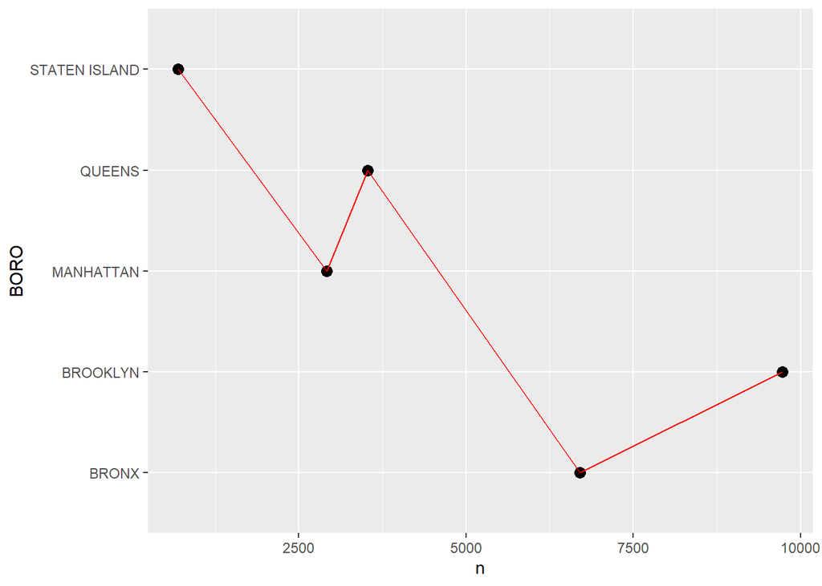

```r
ggplot(data = Shooting_boro_count,
    mapping =aes(x= n, y=BORO, group = 1 ))+
    geom_point(size= 3)+
    geom_line(color = "red")
```

### Another Sample for visualization plot

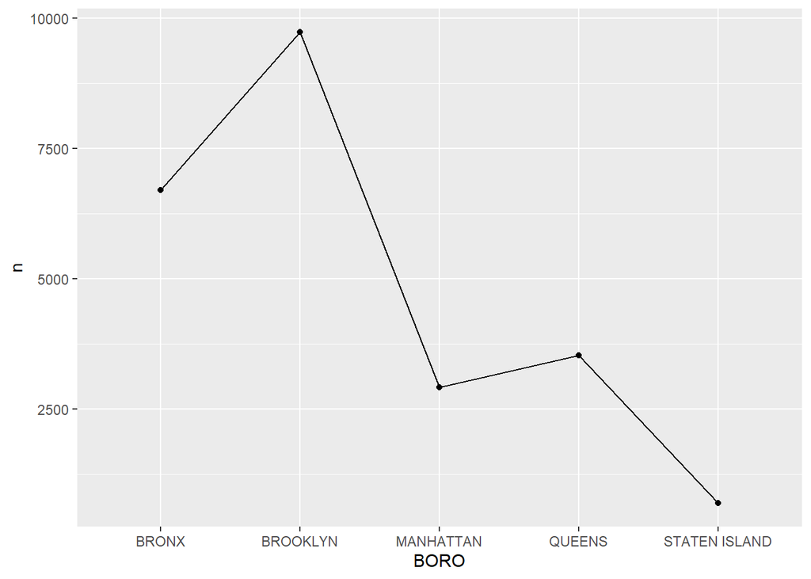

```r
ggplot(Shooting_boro_count,aes(BORO,n, group=1))+ geom_point()+geom_line()
```

### Visualization 3

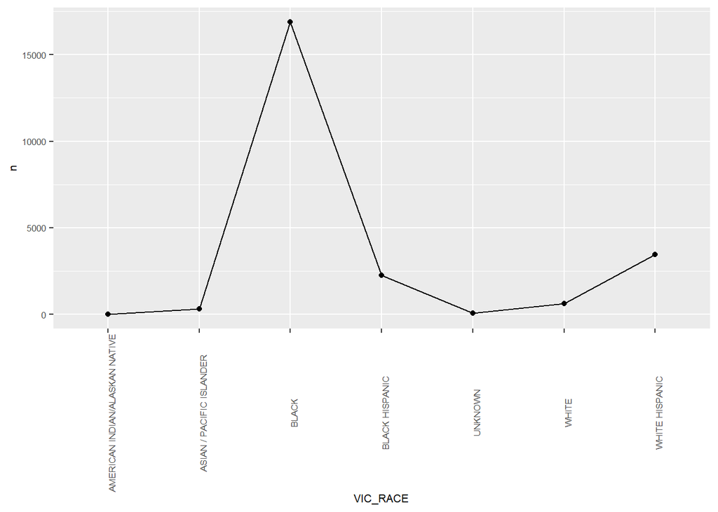

```r
ggplot(Shooting_vic_count,aes( VIC_RACE, n, group=1))+ geom_point()+geom_line()+theme(text=element_text(size=8), axis.text.x = element_text(angle = 90))
```

#### Analysis-Black is the highest victim